# Compare Transcript TPMs - All Experiments (SC as Bulk)

Mervin Fansler

03 December 2023

# Overview

Here we compare mESCs from four datasets:

- Lackford et al., 2014 ([article](https://doi.org/10.1002/embj.201386537) | [data](https://www.ncbi.nlm.nih.gov/sra/SRX304982))
- Nam et al., 2014 ([article](https://doi.org/10.1016/j.molcel.2014.02.013) | [data](https://www.ncbi.nlm.nih.gov/geo/query/acc.cgi?acc=GSM1268958))
- Guo et al., 2019 ([article](https://doi.org/10.1016/j.molcel.2019.01.042) | [data](https://www.ncbi.nlm.nih.gov/sra/SRX5437425))
- Bleckwehl et al., 2021 ([preprint](https://www.biorxiv.org/content/10.1101/2020.07.07.192427v2) | [data](https://www.ncbi.nlm.nih.gov/geo/query/acc.cgi?acc=GSM4694997))

## Data Description

### Cell Cultures

The Lackford data is based on **E14Tg2a** cells ([129/Ola strain](http://www.informatics.jax.org/strain/MGI:2160930)) cultured in [ESGRO Complete PLUS Clonal Grade Medium (Millipore)](https://www.emdmillipore.com/US/en/product/ESGRO-Complete-PLUS-Clonal-Grade-Medium-500ml,MM_NF-SF001-500P), which uses a specific (but proprietary) GSK3β inhibitor and a serum-free condition that does not require LIF.

The Nam data lists [**129S5/SvEvBrd**](http://www.informatics.jax.org/strain/MGI:3487126) as the strain. Culture conditions are not specified in article, supplement, GEO, or SRA.

The Guo data is based on OG2 transgenic mouse embryonic stem cells, with a strain background of 1/2 129SVJ+3/8 C57B6+1/8 CBA. Cells were cultured on feeder layers with 2iL medium (high glucose DMEM, 15%FBS, NEAA, GlutaMAX, LIF) plus 2i (1 mm PD0325901, 3 mm CHIR99021) and LIF.

The Bleckwehl data is based on **E14Tg2a** cells ([129/Ola strain](http://www.informatics.jax.org/strain/MGI:2160930)) cultured in 2i+LIF conditions (serum-free N2B27 medium supplemented with MEK inhibitor PD0325901 [0.4 μM, Miltenyi Biotec], GSK3β inhibitor CHIR99021 [3 μM, Amsbio], and LIF).

### Library Preparation and Sequencing

Lackford used [a direct RNA sequencing protocol](https://dx.doi.org/10.1007%2F978-1-61779-089-8_4) performed by Helicos BioSciences.

Nam used [a 3P-Seq protocol](http://bartellab.wi.mit.edu/protocols/3PSeqV2.pdf) based on [Jan et al., 2011](https://doi.org/10.1038/nature09616), that uses 16-20 amplification cycles.

Bleckwehl and Guo used a 10X Chromium 3’ sequencing kit (v2 chemistry).

### Quantification

Lackford and Nam quantifications come from [PolyASite v2](https://polyasite.unibas.ch/samples) ([pipeline](https://github.com/zavolanlab/polyAsite_workflow)).

Bleckwehl and Guo are quantified through the `scutr-quant` pipeline.

## Parameters

```r
theme_set(theme_bw())
```

# Methods

```r
## Loading PolyASite BED files
mm10_seqinfo <- seqinfo(getBSgenome("mm10")) %>% keepStandardChromosomes

extra_cols_polyasite <- c(pct_samples="numeric", n_protocols="integer",
                          mean_tpm="numeric", region="factor", pas="character")

import_polyasite <- function(...) {
  import(..., format="BED", extraCols=extra_cols_polyasite) %>%
    mutate(tpm=score) %>%
    select(name, tpm, 3:7) %>%
    `seqlevelsStyle<-`("UCSC") %>%
    `seqlevels<-`(value=seqlevels(mm10_seqinfo), pruning.mode='coarse') %>%
    `seqinfo<-`(value=mm10_seqinfo)
}

compute_column_corrs <- function (df, method="spearman", use="complete.obs") {
  df %>%
    as.matrix %>% cor(method=method, use=use) %>%
    `[<-`(lower.tri(.,TRUE), NA) %>%
    as_tibble(rownames="sample1") %>%
    pivot_longer(cols=-1, names_to="sample2", values_to="rho", values_drop_na=TRUE)
}

plot_corrs <- function (df, ylab="Spearman Correlation") {
  ggplot(df, aes(x=type, y=rho, fill=type)) +
    stat_summary(fun='mean', geom='bar', width=0.6, color='black') +
    stat_summary(fun.data=mean_sdl, geom='errorbar', width=0.4) +
    geom_quasirandom(width=0.2, size=0.5) +
    geom_text(aes(x=type, label=str_c("N=", after_stat(count)), y=NULL),
              stat="count", y=0.03, size=3) +
    scale_y_continuous(limits=c(0,1), expand=expansion(add=c(0,0))) +
    labs(x=NULL, y=ylab) +
    guides(fill=FALSE)
}
```

# Load Data

## 10X Data

```r
tx2gene <- read_tsv("data/gtf/mca/utrome.e30.t5.gc25.pas3.f0.9999.w500.m200.tsv")
sc_samples <- c("Guo19"="data/kallisto/guo19/abundance.h5",
                "Bleckwehl21"="data/kallisto/bleckwehl21/abundance.h5")
txsOut <- tximport(sc_samples, type="kallisto", txOut=FALSE, tx2gene=tx2gene[,1:2])
```

```
## 1 2
## summarizing abundance
## summarizing counts
## summarizing length
```

```r
genesOut <- tximport(sc_samples, type="kallisto", txOut=FALSE, tx2gene=tx2gene[,c(1,3)])
```

```
## 1 2
## summarizing abundance
## summarizing counts
## summarizing length
```

```r
cts_tx_sc <- txsOut$counts %>% Matrix(sparse=TRUE)
#cts_gene_sc <- genesOut$counts %>% Matrix(sparse=TRUE)

## need this only for annotations
sce_bleckwehl <- readRDS("data/sce/utrome_mm10_v2/bleckwehl21.txs.Rds")
df_utrome <- rowData(sce_bleckwehl)
gr_utrome <- rowRanges(sce_bleckwehl)
```

```r
gr_nam <- import_polyasite("data/bed/polyasite/nam14/mESC_WT.bed.gz")
gr_lackford <- import_polyasite("data/bed/polyasite/lackford14/mESC_WT.bed.gz")
```

## Filter Data

```r
# Filter to top two non-overlapping UTRs
df_utr2 <- df_utrome %>%
  as_tibble %>%
  dplyr::select(transcript_id, gene_id, gene_name, is_ipa, utr_type_no_ipa) %>%
  mutate(total_umis=rowSums(cts_tx_sc[transcript_id,]),
         tpm=total_umis*1e6/sum(total_umis, na.rm=TRUE)) %>%
  filter(!is_ipa, utr_type_no_ipa == 'multi') %>%
  group_by(gene_id) %>%
  filter(dplyr::n() > 1) %>%
  mutate(utr_rank=row_number(-total_umis)) %>%
  ungroup() %>%
  filter(utr_rank %in% 1:2)

idx_utr2 <- gr_utrome[df_utr2$transcript_id,] %>%
  unlist() %>%
  join_overlap_self_directed() %>%
  filter(transcript_id != transcript_id.overlap) %>%
  { filter(df_utr2, !(transcript_id %in% .$transcript_id)) } %>%
  group_by(gene_id) %>%
  filter(dplyr::n() == 2) %>%
  ungroup() %$%
  transcript_id
```

# TPM

## Compute Bulk

```r
df_nam <- gr_nam %>%
  anchor_center() %>%
  mutate(width=50) %>%
  join_overlap_intersect_directed(x=unlist(gr_utrome[idx_utr2,])) %>%
  group_by(transcript_id) %>%
  summarise(tpm=sum(tpm, na.rm=TRUE)) %>%
  as_tibble() %>%
  dplyr::rename(Nam14=tpm)

df_lackford <- gr_lackford %>%
  anchor_center() %>%
  mutate(width=50) %>%
  join_overlap_intersect_directed(x=unlist(gr_utrome[idx_utr2,])) %>%
  group_by(transcript_id) %>%
  summarise(tpm=sum(tpm, na.rm=TRUE)) %>%
  as_tibble() %>%
  dplyr::rename(Lackford14=tpm)
```

## Compute Single-Cell

```r
cts2tpm <- function (x) x %*% Diagonal(ncol(x), 1e6/colSums(x), names=TRUE)

df_sc <- cts_tx_sc %>% cts2tpm %>%
  `[`(idx_utr2, , drop=FALSE) %>%
  as.matrix %>%
  as_tibble(rownames='transcript_id')
```

## Merge Data

```r
df_tpm <- df_sc %>%
  left_join(df_nam, by='transcript_id') %>%
  left_join(df_lackford, by='transcript_id') %>%
  mutate(across(where(is.numeric), coalesce, 0)) %>%
  left_join(select(df_utr2, transcript_id, gene_id, total_umis, utr_rank),
            by='transcript_id') %>%
  select(transcript_id, gene_id, utr_rank, total_umis, everything())
SAMPLE_COLS=c("Nam14", "Lackford14", "Guo19", "Bleckwehl21")
MIN_TPM=0

df_tpm_min <- df_tpm %>%
  pivot_longer(all_of(SAMPLE_COLS), names_to="sample", values_to="tpm") %>%
  group_by(transcript_id) %>%
  filter(all(tpm > MIN_TPM)) %>%
  ungroup() %>%
  pivot_wider(names_from='sample', values_from='tpm') %>%
  group_by(gene_id) %>%
  filter(dplyr::n() == 2) %>%
  ungroup()
```

# Combined Figures

## TPM

### All genes

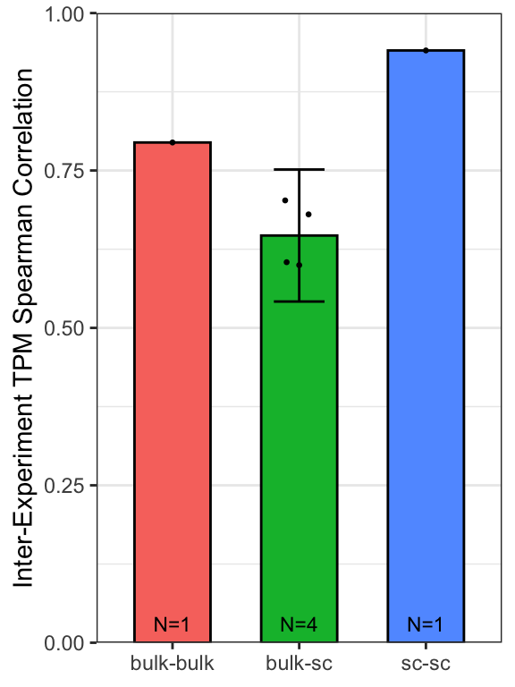

```r
SAMPLE_COLS=c("Lackford14", "Nam14", "Guo19", "Bleckwehl21")
SAMPLES_SC=c("Guo19", "Bleckwehl21")
df_tpm_corrs <- df_tpm[,SAMPLE_COLS] %>%
  compute_column_corrs() %>%
  mutate(type=str_c(ifelse(sample1 %in% SAMPLES_SC, "sc", "bulk"),
               ifelse(sample2 %in% SAMPLES_SC, "sc", "bulk"),
               sep="-"))

plot_corrs(df_tpm_corrs, ylab="Inter-Experiment TPM Spearman Correlation")
```

```r
ggsave("output/figure2/ed2c-mescs-tpm-corrs-bars-sc-as-bulk.pdf", width=3, height=4, dpi=300)
```

### Two-UTR Genes

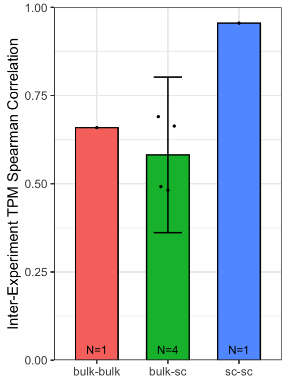

```r
df_tpm_twoutr_corrs <- df_tpm_min[,SAMPLE_COLS] %>%
  compute_column_corrs() %>%
  mutate(type=str_c(ifelse(sample1 %in% SAMPLES_SC, "sc", "bulk"),
               ifelse(sample2 %in% SAMPLES_SC, "sc", "bulk"),
               sep="-"))

plot_corrs(df_tpm_twoutr_corrs, ylab="Inter-Experiment TPM Spearman Correlation")
```

```r
ggsave("output/figure2/ed2c-mescs-tpm-twoutr-corrs-bars-sc-as-bulk.pdf", width=3, height=4, dpi=300)
```

## LUI

### Compute

```r
df_lui <- df_tpm %>%
  pivot_longer(all_of(SAMPLE_COLS), names_to='sample', values_to="tpm") %>%
  group_by(gene_id, sample) %>%
  mutate(lui=tpm/sum(tpm, na.rm=TRUE),
         utr_pos=row_number(as.integer(str_extract(transcript_id,
                                                   "[^.]+$")))) %>%
  filter(utr_pos == max(utr_pos)) %>%
  ungroup() %>%
  select(gene_id, sample, lui) %>%
  pivot_wider(names_from='sample', values_from='lui')
df_lui_min <- df_tpm_min %>%
  pivot_longer(all_of(SAMPLE_COLS), names_to='sample', values_to="tpm") %>%
  group_by(gene_id, sample) %>%
  mutate(lui=tpm/sum(tpm, na.rm=TRUE),
         utr_pos=row_number(as.integer(str_extract(transcript_id,
                                                   "[^.]+$")))) %>%
  filter(utr_pos == max(utr_pos)) %>%
  ungroup() %>%
  select(gene_id, sample, lui) %>%
  pivot_wider(names_from='sample', values_from='lui')
SAMPLE_COLS_LUI=seq(2, ncol(df_lui))
```

### Plot All Multi-UTR

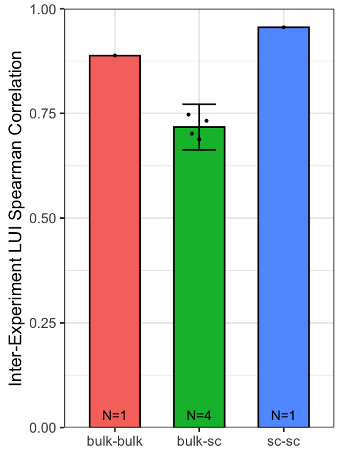

```r
df_lui_corrs <- df_lui[,SAMPLE_COLS_LUI] %>%
  compute_column_corrs() %>%
  mutate(type=str_c(ifelse(sample1 %in% SAMPLES_SC, "sc", "bulk"),
               ifelse(sample2 %in% SAMPLES_SC, "sc", "bulk"),
               sep="-"))

plot_corrs(df_lui_corrs, ylab="Inter-Experiment LUI Spearman Correlation")
```

```r
ggsave("output/figure2/ed2d-mescs-lui-corrs-bars-sc-as-bulk.pdf", width=3, height=4, dpi=300)
```

### Plot Two-UTR

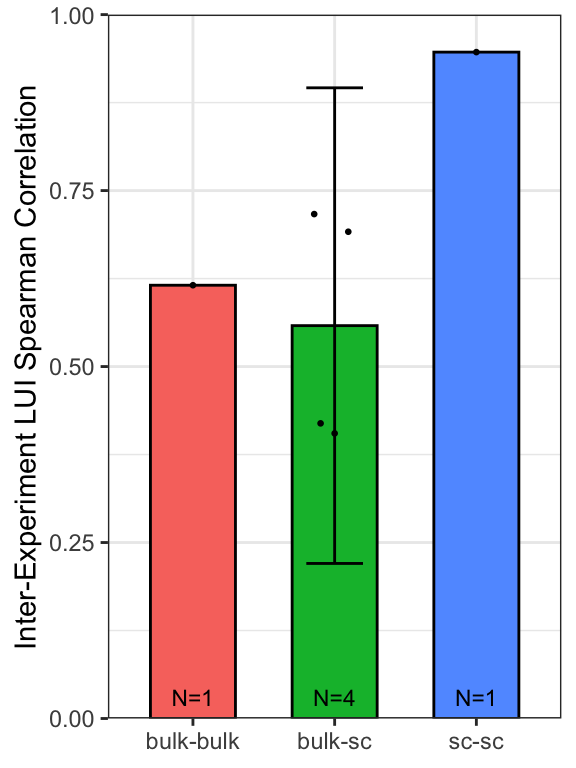

```r
df_lui_twoutr_corrs <- df_lui_min[,SAMPLE_COLS_LUI] %>%
  compute_column_corrs() %>%
  mutate(type=str_c(ifelse(sample1 %in% SAMPLES_SC, "sc", "bulk"),
               ifelse(sample2 %in% SAMPLES_SC, "sc", "bulk"),
               sep="-"))

plot_corrs(df_lui_twoutr_corrs, ylab="Inter-Experiment LUI Spearman Correlation")
```

```r
ggsave("output/figure2/ed2d-mescs-lui-twoutr-corrs-bars-sc-as-bulk.pdf", width=3, height=4, dpi=300)
```

# Table

```r
full_join(df_tpm_corrs, df_lui_twoutr_corrs, by=c("sample1", "sample2", "type"),
          suffix=c(x="_TPM", y="_LUI")) %>%
  select(sample1, sample2, rho_TPM, rho_LUI, type) %>%
  arrange(type, sample1, sample2) %T>%
  write_tsv("output/tables/tbl-mescs-bulk-sc-corrs-sc-as-bulk.tsv")
```

| sample1 | sample2 | rho_TPM | rho_LUI | type |
| --- | --- | --- | --- | --- |
| Lackford14 | Nam14 | 0.7944675 | 0.6155416 | bulk-bulk |
| Lackford14 | Bleckwehl21 | 0.7024648 | 0.7166240 | bulk-sc |
| Lackford14 | Guo19 | 0.6803113 | 0.6915304 | bulk-sc |
| Nam14 | Bleckwehl21 | 0.6043406 | 0.4193160 | bulk-sc |
| Nam14 | Guo19 | 0.5996899 | 0.4050806 | bulk-sc |
| Guo19 | Bleckwehl21 | 0.9406294 | 0.9467242 | sc-sc |

# Runtime Details

## Conda Environment

```
## Conda Environment YAML
name: bioc_3_16
channels:
  - merv
  - conda-forge
  - bioconda
  - defaults
dependencies:
  - _r-mutex=1.0.1=anacondar_1
  - argcomplete=2.0.0=pyhd8ed1ab_0
  - bioconductor-annotate=1.76.0=r42hdfd78af_0
  - bioconductor-annotationdbi=1.60.0=r42hdfd78af_0
  - bioconductor-annotationfilter=1.22.0=r42hdfd78af_0
  - bioconductor-annotationhub=3.6.0=r42hdfd78af_0
  - bioconductor-apeglm=1.20.0=r42hb890f52_0
  - bioconductor-batchelor=1.14.0=r42hb890f52_0
  - bioconductor-beachmat=2.14.0=r42hb890f52_0
  - bioconductor-biobase=2.58.0=r42h3be46a4_0
  - bioconductor-biocfilecache=2.6.0=r42hdfd78af_0
  - bioconductor-biocgenerics=0.44.0=r42hdfd78af_0
  - bioconductor-biocio=1.8.0=r42hdfd78af_0
  - bioconductor-biocneighbors=1.16.0=r42hb890f52_0
  - bioconductor-biocparallel=1.32.0=r42hb890f52_0
  - bioconductor-biocsingular=1.14.0=r42hb890f52_0
  - bioconductor-biocversion=3.16.0=r42hdfd78af_0
  - bioconductor-biomart=2.54.0=r42hdfd78af_0
  - bioconductor-biostrings=2.66.0=r42h3be46a4_0
  - bioconductor-biovizbase=1.46.0=r42h3be46a4_0
  - bioconductor-bluster=1.8.0=r42hb890f52_0
  - bioconductor-bsgenome=1.66.3=r42hdfd78af_0
  - bioconductor-bsgenome.hsapiens.ucsc.hg38=1.4.5=r42hdfd78af_0
  - bioconductor-bsgenome.mmusculus.ucsc.mm10=1.4.3=r42hdfd78af_2
  - bioconductor-celldex=1.8.0=r42hdfd78af_0
  - bioconductor-cellxgenedp=1.2.0=r42hdfd78af_0
  - bioconductor-clusterprofiler=4.6.0=r42hdfd78af_0
  - bioconductor-cner=1.34.0=r42h3be46a4_0
  - bioconductor-data-packages=20230420=hdfd78af_0
  - bioconductor-delayedarray=0.24.0=r42h3be46a4_0
  - bioconductor-delayedmatrixstats=1.20.0=r42hdfd78af_0
  - bioconductor-deseq2=1.38.0=r42hb890f52_0
```

[output cut: 548 more lines]

```
  - xorg-kbproto=1.0.7=h35c211d_1002
  - xorg-libice=1.0.10=h0d85af4_0
  - xorg-libsm=1.2.3=h0d85af4_1000
  - xorg-libx11=1.7.2=h0d85af4_0
  - xorg-libxau=1.0.9=h35c211d_0
  - xorg-libxdmcp=1.1.3=h35c211d_0
  - xorg-libxt=1.2.1=h0d85af4_2
  - xorg-xproto=7.0.31=h35c211d_1007
  - xz=5.2.6=h775f41a_0
  - yaml=0.2.5=h0d85af4_2
  - yq=2.13.0=pyhd8ed1ab_0
  - zipp=3.10.0=pyhd8ed1ab_0
  - zlib=1.2.13=hfd90126_4
  - zstd=1.5.2=hfa58983_4
prefix: /Users/mfansler/miniconda3/envs/bioc_3_16
```